# NYCFlights: Arrival Delay Regression Model

[Shibani Misra]

[10/18/2016]

# NYCFlights Model

Using the rectangular data that you created last week and following the *Predicting Medical Expenses* example from the text (*MLwR*), create a model for arr_delay. Follow MLwR structure for building a model. Describe/Explain each of the steps and show all work in codeblocks below.

## Step 1: Collect Data

```r
options(stringsAsFactors = FALSE)

flights.mod <- read.csv("C:/Users/smisra/tmp/CSX460/03-linear-regression/flightDataWithOtherInfo.csv")
```

## Step 2: Explore and Prep The Data

One of the things not done in the MLwR text is a pairwise comparison between the response and each of the predictors. Make sure to do this; this is often very illustrative of the relationship between that predictor and the response. This can be done with `pairs` or `psych::panel.pairs`

```r
str(flights.mod)
```

```
## 'data.frame':    336776 obs. of  42 variables:
##  $ X             : int  1 2 3 4 5 6 7 8 9 10 ...
##  $ year.x        : int  2013 2013 2013 2013 2013 2013 2013 2013 2013 2013 ...
##  $ month.x       : int  1 1 1 1 1 1 1 1 1 1 ...
##  $ day.x         : int  1 1 1 1 1 1 1 1 1 1 ...
##  $ dep_time      : int  517 533 542 544 554 554 555 557 557 558 ...
##  $ sched_dep_time: int  515 529 540 545 600 558 600 600 600 600 ...
##  $ dep_delay     : int  2 4 2 -1 -6 -4 -5 -3 -3 -2 ...
##  $ arr_time      : int  830 850 923 1004 812 740 913 709 838 753 ...
##  $ sched_arr_time: int  819 830 850 1022 837 728 854 723 846 745 ...
##  $ arr_delay     : int  11 20 33 -18 -25 12 19 -14 -8 8 ...
##  $ carrier       : chr  "UA" "UA" "AA" "B6" ...
##  $ flight        : int  1545 1714 1141 725 461 1696 507 5708 79 301 ...
##  $ tailnum       : chr  "N14228" "N24211" "N619AA" "N804JB" ...
##  $ origin        : chr  "EWR" "LGA" "JFK" "JFK" ...
```

[output cut: 28 more lines]

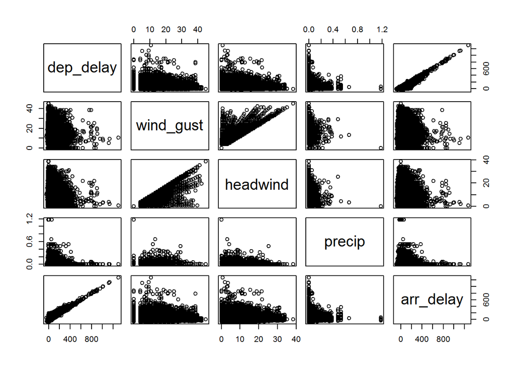

```r
flights.mod <- flights.mod %>%
  filter(is.na(arr_delay)== FALSE)

flights.additionalcols <- flights.mod  %>%
mutate(season = ifelse(month.x %in% c(12,1,2), "Winter", ifelse(month.x %in% c(3,4,5), "Spring", ifelse(month.x %in% c(6,7,8), "Summer", "Fall"))), headwind = cos(wind_dir) * wind_speed,
       wday = weekdays(as.Date(flight_date))) %>%
mutate(season = as.factor(season), wday = as.factor(wday), headwind = abs(headwind))

pairs(flights.additionalcols[c("dep_delay", "wind_gust", "headwind", "precip", "arr_delay")])
```

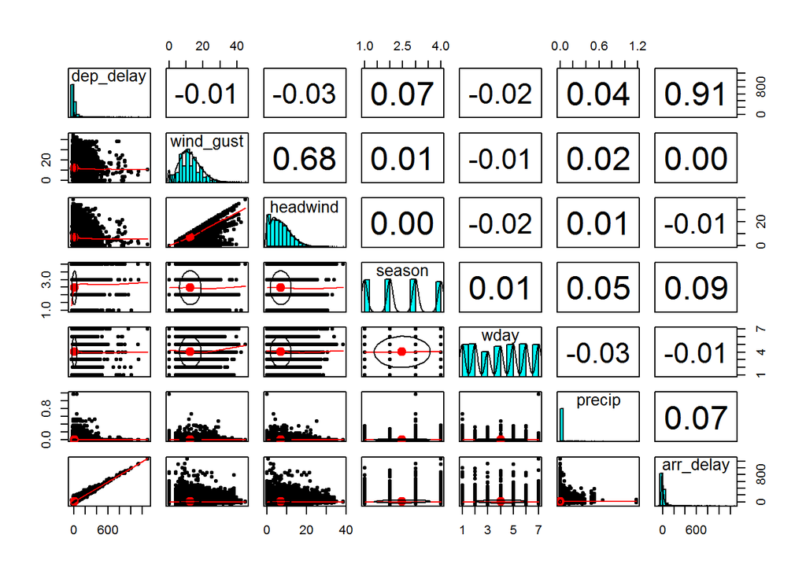

```r
pairs.panels(flights.additionalcols[c("dep_delay", "wind_gust", "headwind", "season", "wday", "precip", "arr_delay")])
```

```r
trainIndex <- createDataPartition(flights.additionalcols$arr_delay, p = .8,
                                  list = FALSE,
                                  times = 1)

flightTrain <- flights.additionalcols[ trainIndex,]
flightTest  <- flights.additionalcols[-trainIndex,]
```

## Step 3: Train The Model

```r
flights.model <- lm(arr_delay ~ dep_delay + wind_gust + headwind + season + wday + precip, data =
                      flightTrain)
summary(flights.model)
```

```
##
## Call:
## lm(formula = arr_delay ~ dep_delay + wind_gust + headwind + season +
##     wday + precip, data = flightTrain)
##
## Residuals:
##     Min      1Q  Median      3Q     Max
## -86.716 -10.827  -1.582   8.779 201.771
##
## Coefficients:
##                 Estimate Std. Error  t value Pr(>|t|)
## (Intercept)   -9.1832316  0.1324683  -69.324  < 2e-16 ***
## dep_delay      1.0145005  0.0008852 1146.101  < 2e-16 ***
## wind_gust      0.0785234  0.0076392   10.279  < 2e-16 ***
## headwind       0.0758210  0.0091982    8.243  < 2e-16 ***
## seasonSpring   0.5116064  0.0998808    5.122 3.02e-07 ***
## seasonSummer   1.9180860  0.1003036   19.123  < 2e-16 ***
## seasonWinter   3.5230227  0.1018804   34.580  < 2e-16 ***
## wdayMonday     0.8342583  0.1299740    6.419 1.38e-10 ***
## wdaySaturday  -2.9686311  0.1393184  -21.308  < 2e-16 ***
## wdaySunday    -0.7746607  0.1321220   -5.863 4.55e-09 ***
## wdayThursday   1.3367248  0.1301060   10.274  < 2e-16 ***
## wdayTuesday    0.6264781  0.1300427    4.817 1.45e-06 ***
## wdayWednesday  1.3034373  0.1300982   10.019  < 2e-16 ***
## precip        63.2246515  1.9260892   32.825  < 2e-16 ***
## ---
## Signif. codes:  0 '***' 0.001 '**' 0.01 '*' 0.05 '.' 0.1 ' ' 1
##
## Residual standard error: 17.87 on 254600 degrees of freedom
##   (7265 observations deleted due to missingness)
## Multiple R-squared:  0.8416, Adjusted R-squared:  0.8416
## F-statistic: 1.041e+05 on 13 and 254600 DF,  p-value: < 2.2e-16
```

## Step 4: Evaluate Performance

```r
flights.predict <- predict(flights.model, flightTest)
```

# Question:

Is this a good model? (Write your answer here.) It is an OK model with a good adjusted R-square and pretty significant independent factors. Could have used some more time to evaluate and improve it.